# Tarea 10

### [Tarea 10] Ejercicios Unidad 04-C | Descomposición LU

- David Pilataxi
- Gr1cc

Link al repositorio:  
https://github.com/DavidPilataxi/Metodos-Enero-Febrero/blob/main/Tarea10/Tarea%2010.ipynb

Resuelva los ejercicios adjuntos.

Indicaciones. -

- Puede realizar los cálculos a mano, o utilizar cualquier librería o implementar su propia función.
- En caso de usar código, subir la resolución de los ejercicios en un repositorio público en Github e incluir enlace de su repositorio.
- Subir archivo pdf.

CONJUNTO DE EJERCICIOS. -

1. Realice las siguientes multiplicaciones matriz-matriz:

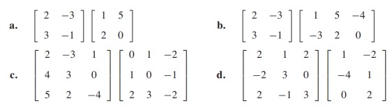

```python
import numpy as np

# Definimos las matrices de cada opción

# Opción a
A_a = np.array([[2, -3], [3, -1]])
B_a = np.array([[1, 5], [2, 0]])
result_a = np.dot(A_a, B_a)

# Opción b
A_b = np.array([[2, -3], [3, -1]])
B_b = np.array([[1, 5, -4], [-3, 2, 0]])
result_b = np.dot(A_b, B_b)

# Opción c
A_c = np.array([[2, -3, 1], [4, 3, 0], [5, 2, -4]])
B_c = np.array([[0, 1, -2], [1, 0, -1], [2, 3, -2]])
result_c = np.dot(A_c, B_c)

# Opción d
A_d = np.array([[2, 1, 2], [-2, 3, 0], [2, -1, 3]])
B_d = np.array([[1, -2], [-4, 1], [0, 2]])
result_d = np.dot(A_d, B_d)

# Mostramos los resultados
print("Resultado opción a:\n", result_a)
print("\nResultado opción b:\n", result_b)
print("\nResultado opción c:\n", result_c)
print("\nResultado opción d:\n", result_d)
```

```
Resultado opción a:
 [[-4 10]
 [ 1 15]]

Resultado opción b:
 [[ 11   4  -8]
 [  6  13 -12]]

Resultado opción c:
 [[ -1   5  -3]
 [  3   4 -11]
 [ -6  -7  -4]]

Resultado opción d:
 [[ -2   1]
 [-14   7]
 [  6   1]]
```

2. Determine cuáles de las siguientes matrices son no singulares y calcule la inversa de esas matrices:

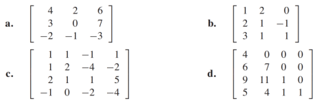

```python
import numpy as np

# Definir matrices con nombres clave
matrices = {
    "A": np.array([[4, 2, 6], [3, 0, 7], [-2, -1, -3]]),
    "B": np.array([[1, 2, 0], [2, 1, -1], [3, 1, 1]]),
    "C": np.array([[1, 1, -1, 1], [1, 2, -4, -2], [2, 1, 1, 5], [-1, 0, -2, -4]]),
    "D": np.array([[4, 0, 0, 0], [6, 7, 0, 0], [9, 11, 1, 0], [5, 4, 1, 1]])
}

# Evaluar cada matriz
for key, mat in matrices.items():
    determinant = np.linalg.det(mat)

    if determinant:
        inverse_matrix = np.linalg.inv(mat)
        print(f"La matriz {key} es no singular (det ≠ 0).")
        print(f"Inversa de {key}:\n{inverse_matrix}\n")
    else:
        print(f"La matriz {key} es singular (det = 0), por lo que no tiene inversa.\n")
```

```
La matriz A es singular (det = 0), por lo que no tiene inversa.

La matriz B es no singular (det ≠ 0).
Inversa de B:
[[-0.25   0.25   0.25 ]
 [ 0.625 -0.125 -0.125]
 [ 0.125 -0.625  0.375]]

La matriz C es singular (det = 0), por lo que no tiene inversa.

La matriz D es no singular (det ≠ 0).
Inversa de D:
[[ 2.50000000e-01 -2.77555756e-17  0.00000000e+00  0.00000000e+00]
 [-2.14285714e-01  1.42857143e-01 -0.00000000e+00 -0.00000000e+00]
 [ 1.07142857e-01 -1.57142857e+00  1.00000000e+00 -0.00000000e+00]
 [-5.00000000e-01  1.00000000e+00 -1.00000000e+00  1.00000000e+00]]
```

3. Resuelva los sistemas lineales 4 x 4 que tienen la misma matriz de coeficientes:

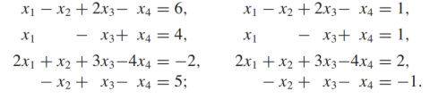

```python
import numpy as np

# Definir la matriz de coeficientes
coef_matrix = np.array([
    [1, -1, 2, -1],
    [1, 0, -1, 1],
    [2, 1, 3, -4],
    [0, -1, 1, -1]
])

# Definir los vectores de términos independientes
rhs_vectors = {
    "Sistema 1": np.array([6, 4, -2, 5]),
    "Sistema 2": np.array([1, 1, 2, -1])
}

# Resolver los sistemas de ecuaciones
solutions = {name: np.linalg.solve(coef_matrix, vec) for name, vec in rhs_vectors.items()}

# Imprimir resultados
for system, solution in solutions.items():
    print(f"{system} - Solución:\n{solution}\n")
```

```
Sistema 1 - Solución:
[ 3. -6. -2. -1.]

Sistema 2 - Solución:
[1. 1. 1. 1.]
```

```python
import sympy as sp

# Definir la variable simbólica
α = sp.Symbol('α')

# Definir la matriz A con α como parámetro
matrix_A = sp.Matrix([
    [1, -1, α],
    [2, 2, 1],
    [0, α, -3/2]
])

# Calcular el determinante de A
determinant_A = matrix_A.det()

# Encontrar los valores de α que hacen singular a la matriz (det = 0)
singular_values = sp.solve(determinant_A, α)

# Mostrar resultados
print(f"Determinante de A: {determinant_A}")
print(f"Valores de α que hacen que A sea singular: {singular_values}")
```

```
Determinante de A: 2*α**2 - α - 6.0
Valores de α que hacen que A sea singular: [-1.50000000000000, 2.00000000000000]
```

5. Resuelva los siguientes sistemas lineales:

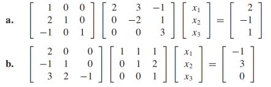

```python
import sympy as sp

# Definir variables simbólicas
x_1, x_2, x_3 = sp.symbols('x_1 x_2 x_3')
X_vector = sp.Matrix([x_1, x_2, x_3])

# Definir matrices para el sistema A
matrix_A1 = sp.Matrix([
    [1, 0, 0],
    [2, 1, 0],
    [-1, 0, 1]
])

matrix_B1 = sp.Matrix([
    [2, 3, -1],
    [0, -2, 1],
    [0, 0, 3]
])

vector_C1 = sp.Matrix([2, -1, 1])

# Resolver el sistema A
solution_A = sp.solve(matrix_A1 * (matrix_B1 * X_vector) - vector_C1, [x_1, x_2, x_3])

# Definir matrices para el sistema B
matrix_A2 = sp.Matrix([
    [2, 0, 0],
    [-1, 1, 0],
    [3, 2, -1]
])

matrix_B2 = sp.Matrix([
    [1, 1, 1],
    [0, 1, 2],
    [0, 0, 1]
])

vector_C2 = sp.Matrix([-1, 3, 0])

# Resolver el sistema B
solution_B = sp.solve(matrix_A2 * (matrix_B2 * X_vector) - vector_C2, [x_1, x_2, x_3])

# Imprimir soluciones
print("Solución del sistema A:", solution_A)
print("Solución del sistema B:", solution_B)
```

```
Solución del sistema A: {x_1: -3, x_2: 3, x_3: 1}
Solución del sistema B: {x_1: 1/2, x_2: -9/2, x_3: 7/2}
```

6. Factorice las siguientes matrices en la descomposición LU mediante el algoritmo de factorización *LU* con lii=1 para todas las i

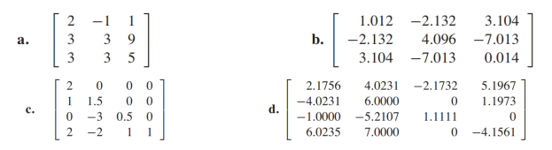

```python
import sympy as sp

def lu_decomposition(mat, decimals=4):
    """Realiza la descomposición LU con l_ii = 1 para todas las i y trunca a 'decimals' decimales."""
    size = mat.shape[0]
    lower = sp.eye(size)
    upper = mat.copy()

    for row in range(size):
        for col in range(row + 1, size):
            multiplier = upper[col, row] / upper[row, row]
            lower[col, row] = multiplier
            upper[col, :] -= multiplier * upper[row, :]

    # Redondear matrices
    lower = lower.applyfunc(lambda x: round(x, decimals))
    upper = upper.applyfunc(lambda x: round(x, decimals))

    return lower, upper

# Definir las matrices
matrices = {
    "A": sp.Matrix([
        [2, -1, 1],
        [3, 3, 9],
        [3, 3, 5]
    ]),
    "B": sp.Matrix([
        [1.012, -2.132, 3.104],
        [-2.132, 4.096, -7.013],
        [3.104, -7.013, 0.014]
    ]),
    "C": sp.Matrix([
        [2, 0, 0, 0],
        [1, 1.5, 0, 0],
        [0, -3, 0.5, 0],
        [2, -2, 1, 1]
    ]),
    "D": sp.Matrix([
        [2.1756, 4.0231, -2.1732, 5.1967],
        [-4.0231, 6.0000, 0, 1.1973],
        [-1.0000, -5.2107, 1.1111, 0],
        [6.0235, 7.0000, 0, -4.1561]
    ])
}

# Aplicar factorización LU a cada matriz
for name, matrix in matrices.items():
    L, U = lu_decomposition(matrix)
    print(f"Factorización LU de la matriz {name}:")
    print(f"L:\n{L}\nU:\n{U}\n")
```

```
Factorización LU de la matriz A:
L:
Matrix([[1, 0, 0], [1.5000, 1, 0], [1.5000, 1, 1]])
U:
Matrix([[2, -1, 1], [0, 4.5000, 7.5000], [0, 0, -4]])

Factorización LU de la matriz B:
L:
Matrix([[1, 0, 0], [-2.1067, 1, 0], [3.0672, 1.1978, 1]])
U:
Matrix([[1.0120, -2.1320, 3.1040], [0, -0.3955, -0.4737], [0, 0, -8.9391]])

Factorización LU de la matriz C:
L:
Matrix([[1, 0, 0, 0], [0.5000, 1, 0, 0], [0, -2.00000000000000, 1, 0], [1, -1.3333, 2.00000000000000, 1]])
U:
Matrix([[2, 0, 0, 0], [0, 1.5000, 0, 0], [0, 0, 0.5000, 0], [0, 0, 0, 1]])

Factorización LU de la matriz D:
L:
Matrix([[1, 0, 0, 0], [-1.8492, 1, 0, 0], [-0.4596, -0.2501, 1, 0], [2.7687, -0.3079, -5.3523, 1]])
U:
Matrix([[2.1756, 4.0231, -2.1732, 5.1967], [0, 13.4395, -4.0187, 10.8070], [0, 0, -0.8930, 5.0917], [0, 0, 0, 12.0361]])
```

y, a continuación, resuelva los siguientes sistemas lineales.

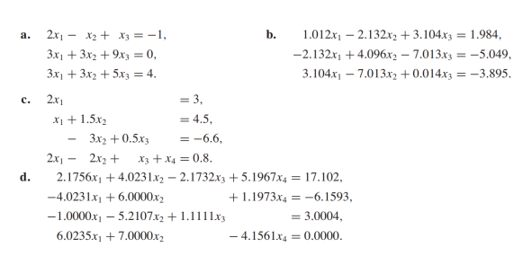

```python
import numpy as np

def lu_decompose(matrix):
    """Descomposición LU con Lii = 1 para todas las i."""
    n = len(matrix)
    L = np.eye(n)  # Matriz L con diagonal de unos
    U = np.zeros((n, n))

    for i in range(n):
        for j in range(i, n):
            U[i, j] = matrix[i, j] - sum(L[i, k] * U[k, j] for k in range(i))

        for j in range(i + 1, n):
            L[j, i] = (matrix[j, i] - sum(L[j, k] * U[k, i] for k in range(i))) / U[i, i]

    return L, U

def forward_subst(L, b):
    """Sustitución progresiva para resolver Ly = b."""
    n = len(b)
    y = np.zeros(n)

    for i in range(n):
        y[i] = b[i] - sum(L[i, j] * y[j] for j in range(i))

    return y

def backward_subst(U, y):
    """Sustitución regresiva para resolver Ux = y."""
    n = len(y)
    x = np.zeros(n)

    for i in range(n - 1, -1, -1):
        x[i] = (y[i] - sum(U[i, j] * x[j] for j in range(i + 1, n))) / U[i, i]

    return x

def solve_system(A, b):
    """Resuelve el sistema Ax = b usando descomposición LU."""
    L, U = lu_decompose(A)
    y = forward_subst(L, b)
    x = backward_subst(U, y)
    return np.round(x, 4)  # Redondear la solución a 4 decimales

# Definir sistemas de ecuaciones
systems = {
    "a": {
        "A": np.array([
            [2, -1, 1],
            [3, 3, 9],
            [3, 3, 5]
        ]),
        "b": np.array([-1, 0, 4])
    },
    "b": {
        "A": np.array([
            [1.012, -2.132, 3.104],
            [-2.132, 4.096, -7.013],
            [3.104, -7.013, 0.014]
        ]),
        "b": np.array([1.984, -5.049, -3.895])
    },
    "c": {
        "A": np.array([
            [2, 0, 0, 0],
            [1, 1.5, 0, 0],
            [0, -3, 0.5, 0],
            [0, -2, 1, 1]
        ]),
        "b": np.array([3, 4.5, -6.6, 0.8])
    },
    "d": {
        "A": np.array([
            [2.1756, 4.0231, -2.1732, 5.1967],
            [-4.0231, 6.0000, 0, 1.1973],
            [-1.0000, -5.2107, 1.1111, 0],
            [6.0235, 7.0000, 0, -4.1561]
        ]),
        "b": np.array([17.102, -6.1593, 3.0004, 0])
    }
}

# Resolver cada sistema
for label, system in systems.items():
    A, b = system["A"], system["b"]
    solution = solve_system(A, b)
    print(f"Solución del sistema {label}: {solution}\n")
```

```
Solución del sistema a: [ 1.  2. -1.]

Solución del sistema b: [1. 1. 1.]

Solución del sistema c: [ 1.5  2.  -1.2  6. ]

Solución del sistema d: [2.9399 0.0707 5.6777 4.3798]
```